# Propser Loan Dataset Exploration

## by Moyinoluwa Sobowale

## Investigation Overview

> For the presentation, my goal is to explore the features of interest to discover the relationship between the borrowers and the loans disbursed to them. I will be investigating how each feature relates to one another and finally, how their correlation is affected by other variables in the dataset.

## Dataset Overview

> The dataset being used for this project is the Prosper loan Dataset provided by Udacity containing information of 113,937 loans with 81 variables(columns) on each loan. [Find column details here](https://docs.google.com/spreadsheets/d/1gDyi_L4UvIrLTEC6Wri5nbaMmkGmLQBk-Yx3z0XDEtI/edit#gid=0).

> Out of 81 loan features, I selected 20 columns and stored them in a dataframe called 'loan' for my analysis including 5 major columns of interest, which are: 'BorrowerAPR', 'BorrowerRate', 'LoanOriginalAmount', 'LoanOriginalDate', 'Term'.

## DISTRIBUTION OF HOME OWNERS AMONG THE BORROWERS

> - A doughnut chart was created to gain insight into the distribution of home ownership accross the borrowers.
> - We can see that 50.4% of the borrowers are homeowners while 49.6% of the borrowers are not. The distribution chart shows an almost even distribution between borrowers who own a home and those who do not.
> - This implies that home ownership might not have a significant effect on getting a loan from Prosper.

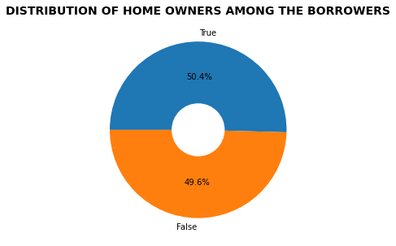

## DISTRIBUTION OF BORROWERS ACROSS THE 51 STATES

> A countplot (horizontal barchart) was created to show the distribution of the borrower states. Carlifonia is the state with the highest number of borrowers, they are approximately 14717 counti.e over 14000 count. North Dakota is the state with the least number of borrowers.

```
''
```

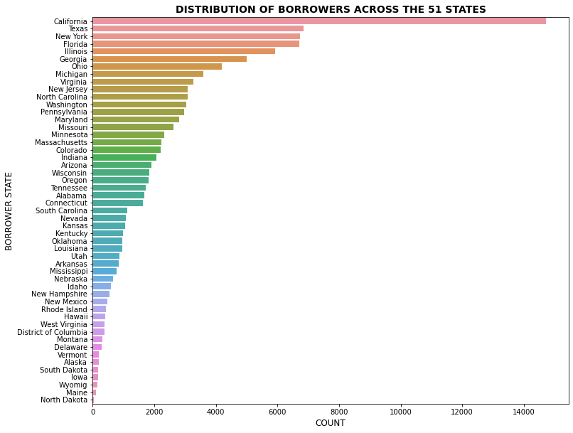

## DISTRIBUTION OF BORROWERS' EMPLOYEMENT STATUS

> An horizontal countplot(barchart) was created to gain insight into the borrower's employment status. We can see that majority of the borrowers are employed i.e almost 70,000 of them.

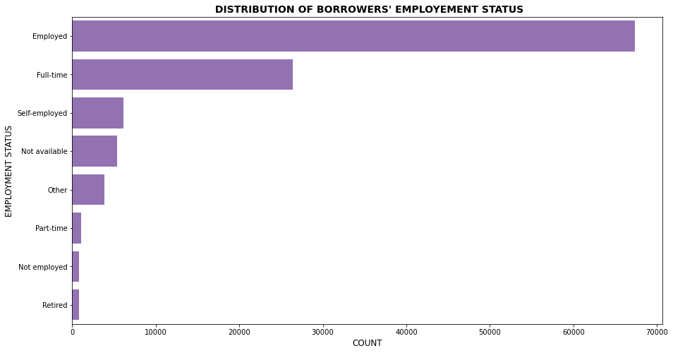

## DISTRIBUTION OF BORROWERS' INCOME RANGE

> An horizontal countplot (barchart) was created to gain insight into the borrower's income range. The distribution shows us that majority of the borrowers are of the income range 25,000 - 74,999 dollars range

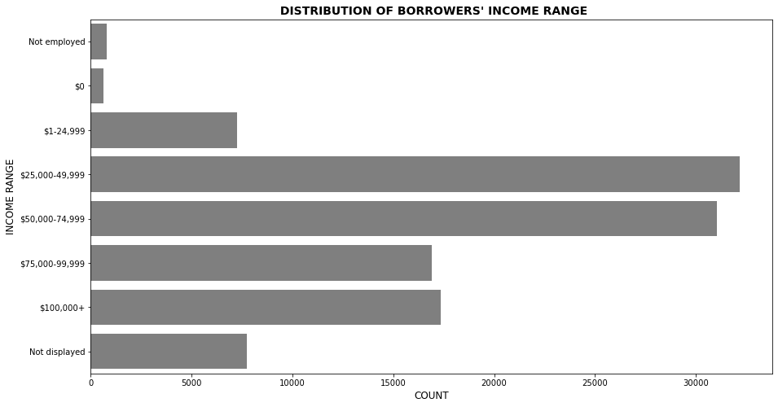

## DISTRIBUTION OF LOAN YEARS

> An horizontal countplot (barchart) was created to gain insight into the distribution of the loan years. This distribution shows us that majority of the loans were taken in 2013 (almost 35,000 loans), no loan was taken in 2005.

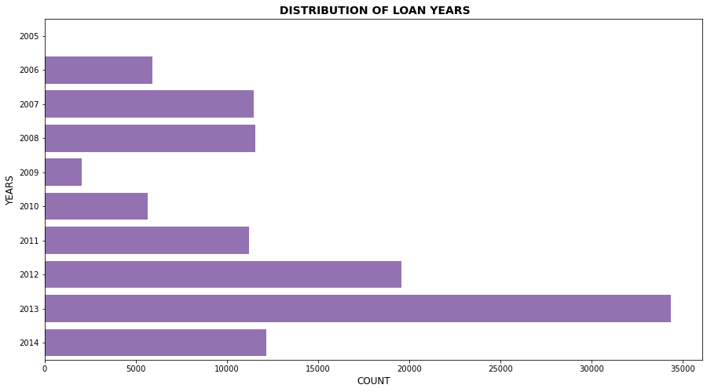

## RELATIONSHIP BETWEEN EMPLOYMENT STATUS AND HOME OWNERSHIP

> The barchart shows us that majority of the employed borrowers are homeowners

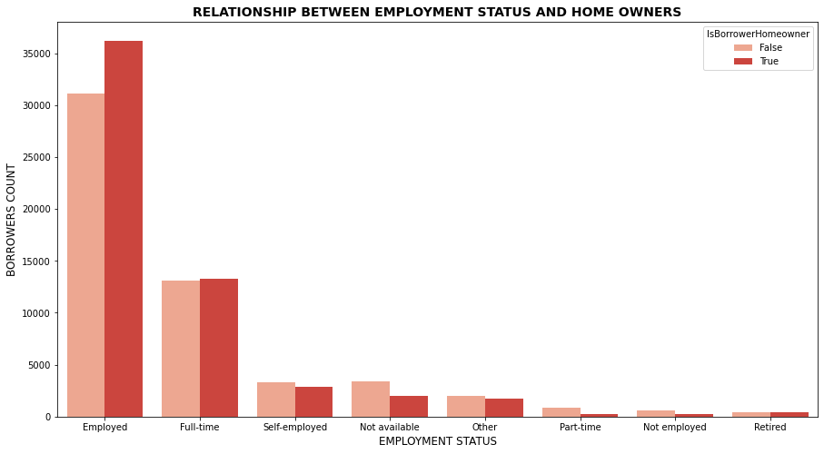

## RELATIONSHIP BETWEEN EMPLOYMENT STATUS AND LOAN TERM

> The chart shows us that the borrowers with full time employment status tend to take loans with term duration of 36months. Majority of the employed borrowers tend to take loans with 36months duration.

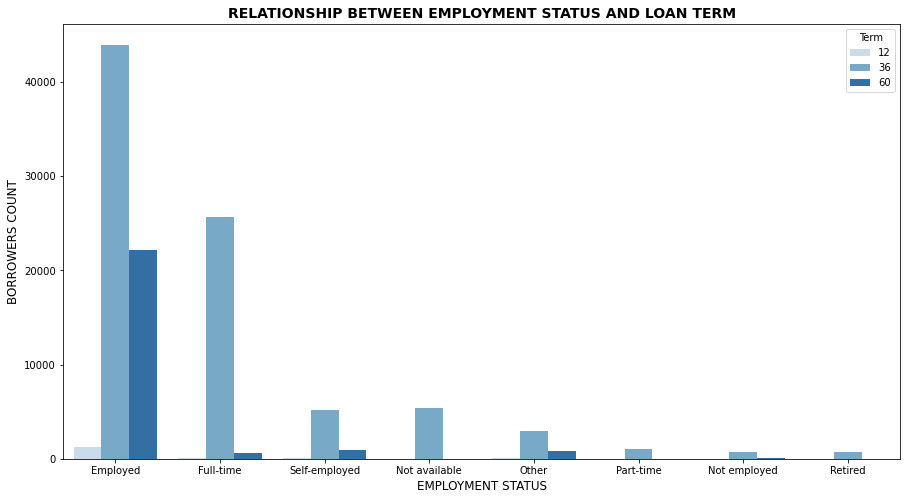

## CORRELATION BETWEEN BORROWER APR, BORROWER RATE, LOAN AMOUNT AND STATED MONTHLY INCOME

> The heatmap tells us the following:
> - The correlation coefficient indicates that the borrower rate and borrower APR a have strong positive correlation meaning that they are directly proportional i.e the rise in one vale leads to the rise in the other.
> - We can also see that the Loan original amount has a weak correlation with the borrowers rate and borrower APR. This means that the borrower rate and borrower APR are negatively correlated with the loan original amount. Therefore, the higher the loan amount, the lower the Borrower Rate and Borrower APR.
> - The loan original amount is positively correlated with the stated monthly income. Therefore, the higher the stated monthly income, the higher the original loan amount received by the borrower.

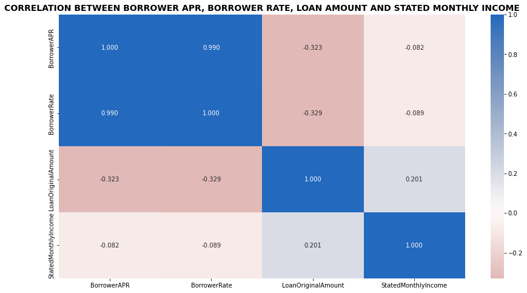

## RELATIONSHIP BETWEEN INCOME RANGE AND LOAN AMOUNT BASED ON INCOME VERIFIABLE

> The boxplot shows us that borrowers who earn 100,000+ dollars and have verified their income tend to get larger loan original amount than those whose income are not verifiable. The borrowers with verified incomes seem to get higher loan amounts. Therefore, having verifiable income seems to be crucial when giving out loans to borrowers.

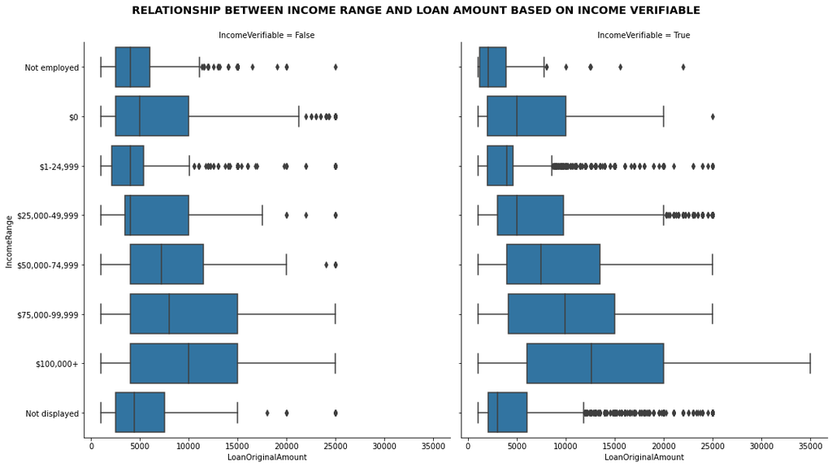